```python
import pandas as pd
import numpy as np
import matplotlib.pyplot as plt
```

# question 1

یک فایلcsv در اختیار ما قرار داده شده که است. در این فایل 891 سطر و 12 ستون داریم که اطلاعات زیر را نشان می دهند. 1. نوع بلیط 2. جنسیت 3. سن 4. تعداد خواهر، برادر یا همسران هر شخص در کشتی 5. تعداد والدین یا فرزندان هر شخص در کشتی 6. شماره بلیط 7. کرایه بلیط مسافر 8. شماره کابین 9. .بندری که در آن مسافر سوار شد ه است حال این فایل را با کمک کتابخانه pandas باز میکنیم.

```python
df_train = pd.read_csv("train.csv")
df_train
```

|  | PassengerId | Survived | Pclass | Name | Sex | Age | SibSp | Parch | Ticket | Fare | Cabin | Embarked |
| --- | --- | --- | --- | --- | --- | --- | --- | --- | --- | --- | --- | --- |
| 0 | 1 | 0 | 3 | Braund, Mr. Owen Harris | male | 22.0 | 1 | 0 | A/5 21171 | 7.2500 | NaN | S |
| 1 | 2 | 1 | 1 | Cumings, Mrs. John Bradley (Florence Briggs Th... | female | 38.0 | 1 | 0 | PC 17599 | 71.2833 | C85 | C |
| 2 | 3 | 1 | 3 | Heikkinen, Miss. Laina | female | 26.0 | 0 | 0 | STON/O2. 3101282 | 7.9250 | NaN | S |
| 3 | 4 | 1 | 1 | Futrelle, Mrs. Jacques Heath (Lily May Peel) | female | 35.0 | 1 | 0 | 113803 | 53.1000 | C123 | S |
| 4 | 5 | 0 | 3 | Allen, Mr. William Henry | male | 35.0 | 0 | 0 | 373450 | 8.0500 | NaN | S |
| ... | ... | ... | ... | ... | ... | ... | ... | ... | ... | ... | ... | ... |
| 886 | 887 | 0 | 2 | Montvila, Rev. Juozas | male | 27.0 | 0 | 0 | 211536 | 13.0000 | NaN | S |
| 887 | 888 | 1 | 1 | Graham, Miss. Margaret Edith | female | 19.0 | 0 | 0 | 112053 | 30.0000 | B42 | S |
| 888 | 889 | 0 | 3 | Johnston, Miss. Catherine Helen "Carrie" | female | NaN | 1 | 2 | W./C. 6607 | 23.4500 | NaN | S |
| 889 | 890 | 1 | 1 | Behr, Mr. Karl Howell | male | 26.0 | 0 | 0 | 111369 | 30.0000 | C148 | C |
| 890 | 891 | 0 | 3 | Dooley, Mr. Patrick | male | 32.0 | 0 | 0 | 370376 | 7.7500 | NaN | Q |

891 rows × 12 columns

تابع head پنج عنصر اول این دیتاست را نمایش میدهد. در این حالت تمامی ستون ها را برای این پنج عنصر نشان میدهد.

```python
df_train.head()
```

|  | PassengerId | Survived | Pclass | Name | Sex | Age | SibSp | Parch | Ticket | Fare | Cabin | Embarked |
| --- | --- | --- | --- | --- | --- | --- | --- | --- | --- | --- | --- | --- |
| 0 | 1 | 0 | 3 | Braund, Mr. Owen Harris | male | 22.0 | 1 | 0 | A/5 21171 | 7.2500 | NaN | S |
| 1 | 2 | 1 | 1 | Cumings, Mrs. John Bradley (Florence Briggs Th... | female | 38.0 | 1 | 0 | PC 17599 | 71.2833 | C85 | C |
| 2 | 3 | 1 | 3 | Heikkinen, Miss. Laina | female | 26.0 | 0 | 0 | STON/O2. 3101282 | 7.9250 | NaN | S |
| 3 | 4 | 1 | 1 | Futrelle, Mrs. Jacques Heath (Lily May Peel) | female | 35.0 | 1 | 0 | 113803 | 53.1000 | C123 | S |
| 4 | 5 | 0 | 3 | Allen, Mr. William Henry | male | 35.0 | 0 | 0 | 373450 | 8.0500 | NaN | S |

تابع info اطلاعات مربوط به دیتاست را نمایش میدهد. به صورتی که تعداد سطر و ستون، همچنین اطلاعات مربوط به هر ستون یعنی تایپ داده های ان ستون ،تعداد داده های غیر null را نشان میدهد.

```python
df_train.info()
```

```
<class 'pandas.core.frame.DataFrame'>
RangeIndex: 891 entries, 0 to 890
Data columns (total 12 columns):
 #   Column       Non-Null Count  Dtype
---  ------       --------------  -----
 0   PassengerId  891 non-null    int64
 1   Survived     891 non-null    int64
 2   Pclass       891 non-null    int64
 3   Name         891 non-null    object
 4   Sex          891 non-null    object
 5   Age          714 non-null    float64
 6   SibSp        891 non-null    int64
 7   Parch        891 non-null    int64
 8   Ticket       891 non-null    object
 9   Fare         891 non-null    float64
 10  Cabin        204 non-null    object
 11  Embarked     889 non-null    object
dtypes: float64(2), int64(5), object(5)
memory usage: 83.7+ KB
```

تابع tail پنج عنصر اخر دیتاست را نشان میدهد.

```python
df_train.tail()
```

|  | PassengerId | Survived | Pclass | Name | Sex | Age | SibSp | Parch | Ticket | Fare | Cabin | Embarked |
| --- | --- | --- | --- | --- | --- | --- | --- | --- | --- | --- | --- | --- |
| 886 | 887 | 0 | 2 | Montvila, Rev. Juozas | male | 27.0 | 0 | 0 | 211536 | 13.00 | NaN | S |
| 887 | 888 | 1 | 1 | Graham, Miss. Margaret Edith | female | 19.0 | 0 | 0 | 112053 | 30.00 | B42 | S |
| 888 | 889 | 0 | 3 | Johnston, Miss. Catherine Helen "Carrie" | female | NaN | 1 | 2 | W./C. 6607 | 23.45 | NaN | S |
| 889 | 890 | 1 | 1 | Behr, Mr. Karl Howell | male | 26.0 | 0 | 0 | 111369 | 30.00 | C148 | C |
| 890 | 891 | 0 | 3 | Dooley, Mr. Patrick | male | 32.0 | 0 | 0 | 370376 | 7.75 | NaN | Q |

تابع decribe چند عنصر مختلف را نمایش میدهد. برای هر ستون تعداد داده های غیر null را حساب میکند. میانگین و انحراف از معیار هر ستوان را نشان میدهد. همچنین مینیمم و ماکسیمم و چارک اول و میانه و چارک سوم را نیز نشان میدهد.

```python
df_train.describe()
```

|  | PassengerId | Survived | Pclass | Age | SibSp | Parch | Fare |
| --- | --- | --- | --- | --- | --- | --- | --- |
| count | 891.000000 | 891.000000 | 891.000000 | 714.000000 | 891.000000 | 891.000000 | 891.000000 |
| mean | 446.000000 | 0.383838 | 2.308642 | 29.699118 | 0.523008 | 0.381594 | 32.204208 |
| std | 257.353842 | 0.486592 | 0.836071 | 14.526497 | 1.102743 | 0.806057 | 49.693429 |
| min | 1.000000 | 0.000000 | 1.000000 | 0.420000 | 0.000000 | 0.000000 | 0.000000 |
| 25% | 223.500000 | 0.000000 | 2.000000 | 20.125000 | 0.000000 | 0.000000 | 7.910400 |
| 50% | 446.000000 | 0.000000 | 3.000000 | 28.000000 | 0.000000 | 0.000000 | 14.454200 |
| 75% | 668.500000 | 1.000000 | 3.000000 | 38.000000 | 1.000000 | 0.000000 | 31.000000 |
| max | 891.000000 | 1.000000 | 3.000000 | 80.000000 | 8.000000 | 6.000000 | 512.329200 |

# question 2

ستون های جنسیت، اسم، بلیط، کابین و بندر به صورت دسته ای هستند. در ادامه ستون های بندر و جنسیت را به نوع عددی تبدیل میکنیم. بقیه ستون ها چون مقادیر متنوع دارند و اطلاعاتی به ما نمیدهند را به عددی تبدیل نمیکنیم.

```python
df_train.info()
```

```
<class 'pandas.core.frame.DataFrame'>
RangeIndex: 891 entries, 0 to 890
Data columns (total 12 columns):
 #   Column       Non-Null Count  Dtype
---  ------       --------------  -----
 0   PassengerId  891 non-null    int64
 1   Survived     891 non-null    int64
 2   Pclass       891 non-null    int64
 3   Name         891 non-null    object
 4   Sex          891 non-null    object
 5   Age          714 non-null    float64
 6   SibSp        891 non-null    int64
 7   Parch        891 non-null    int64
 8   Ticket       891 non-null    object
 9   Fare         891 non-null    float64
 10  Cabin        204 non-null    object
 11  Embarked     889 non-null    object
dtypes: float64(2), int64(5), object(5)
memory usage: 83.7+ KB
```

```python
categorical = df_train.dtypes[df_train.dtypes == "object"].index.values.tolist()
print(categorical)
```

```
['Name', 'Sex', 'Ticket', 'Cabin', 'Embarked']
```

```python
df_train['Sex'].value_counts()
```

```
male      577
female    314
Name: Sex, dtype: int64
```

```python
df_train['Sex'].replace(['male','female'],[0,1],inplace=True)
```

```python
df_train['Embarked'].value_counts()
```

```
S    644
C    168
Q     77
Name: Embarked, dtype: int64
```

```python
df_train['Embarked'].replace(['S','C','Q'],[0,1,2],inplace=True)
```

```python
df_train.head()
```

|  | PassengerId | Survived | Pclass | Name | Sex | Age | SibSp | Parch | Ticket | Fare | Cabin | Embarked |
| --- | --- | --- | --- | --- | --- | --- | --- | --- | --- | --- | --- | --- |
| 0 | 1 | 0 | 3 | Braund, Mr. Owen Harris | 0 | 22.0 | 1 | 0 | A/5 21171 | 7.2500 | NaN | 0.0 |
| 1 | 2 | 1 | 1 | Cumings, Mrs. John Bradley (Florence Briggs Th... | 1 | 38.0 | 1 | 0 | PC 17599 | 71.2833 | C85 | 1.0 |
| 2 | 3 | 1 | 3 | Heikkinen, Miss. Laina | 1 | 26.0 | 0 | 0 | STON/O2. 3101282 | 7.9250 | NaN | 0.0 |
| 3 | 4 | 1 | 1 | Futrelle, Mrs. Jacques Heath (Lily May Peel) | 1 | 35.0 | 1 | 0 | 113803 | 53.1000 | C123 | 0.0 |
| 4 | 5 | 0 | 3 | Allen, Mr. William Henry | 0 | 35.0 | 0 | 0 | 373450 | 8.0500 | NaN | 0.0 |

# question 3

در این بخش با تابع isnull میتوانیم تک تک سلول های دیتا ست را بررسی کنیم. همچنین با sum گرفتن میتوانیم تعداد null های هر ستون را به دست اوریم. در ادامه با میانگین خانه های خالی سن را پر میکنیم. چون سن یک مقدار پیوسته است استفاده از میانگین در این بخش ایده خوبیست. خانه های خالی بندر را نیز با mode یا همان پر تکرار ترین عنصر ان ستون پر میکنیم. چون با مقادیر گسسته رو به رو هستیم، استفاده از میانگین درست نمیباشد. از خوبی های استفاده از میانگین این است که محاسبات پیچیده ای ندارد ولی این روش میتواند منجر به از دست رفتن اطلاعات شود. زمانی استفاده از میانگین مناسب است که پراکندگی یا واریانس داده ها کم باشد. اگر داده ها خیلی پراکنده باشند ، پر کردن با میانگین منجر به نتایج نادرست می شود.

```python
df_train.isnull()
```

|  | PassengerId | Survived | Pclass | Name | Sex | Age | SibSp | Parch | Ticket | Fare | Cabin | Embarked |
| --- | --- | --- | --- | --- | --- | --- | --- | --- | --- | --- | --- | --- |
| 0 | False | False | False | False | False | False | False | False | False | False | True | False |
| 1 | False | False | False | False | False | False | False | False | False | False | False | False |
| 2 | False | False | False | False | False | False | False | False | False | False | True | False |
| 3 | False | False | False | False | False | False | False | False | False | False | False | False |
| 4 | False | False | False | False | False | False | False | False | False | False | True | False |
| ... | ... | ... | ... | ... | ... | ... | ... | ... | ... | ... | ... | ... |
| 886 | False | False | False | False | False | False | False | False | False | False | True | False |
| 887 | False | False | False | False | False | False | False | False | False | False | False | False |
| 888 | False | False | False | False | False | True | False | False | False | False | True | False |
| 889 | False | False | False | False | False | False | False | False | False | False | False | False |
| 890 | False | False | False | False | False | False | False | False | False | False | True | False |

891 rows × 12 columns

```python
df_train.isnull().sum()
```

```
PassengerId      0
Survived         0
Pclass           0
Name             0
Sex              0
Age            177
SibSp            0
Parch            0
Ticket           0
Fare             0
Cabin          687
Embarked         2
dtype: int64
```

```python
mean_age = df_train['Age'].mean()
df_train['Age'] = df_train['Age'].fillna(mean_age)

mode_embarked = df_train['Embarked'].mode()[0]
df_train['Embarked'] = df_train['Embarked'].fillna(mode_embarked)

df_train.isnull().sum()
```

```
PassengerId      0
Survived         0
Pclass           0
Name             0
Sex              0
Age              0
SibSp            0
Parch            0
Ticket           0
Fare             0
Cabin          687
Embarked         0
dtype: int64
```

# question 4

ستون های اسم و id و بلیط و کابین به دلیل اینکه مقادیر منحصر به فردی دارند و اطلاعات خاصی به ما نمیدهند را حذف میکنیم.

```python
df_train.head()
```

|  | PassengerId | Survived | Pclass | Name | Sex | Age | SibSp | Parch | Ticket | Fare | Cabin | Embarked |
| --- | --- | --- | --- | --- | --- | --- | --- | --- | --- | --- | --- | --- |
| 0 | 1 | 0 | 3 | Braund, Mr. Owen Harris | 0 | 22.0 | 1 | 0 | A/5 21171 | 7.2500 | NaN | 0.0 |
| 1 | 2 | 1 | 1 | Cumings, Mrs. John Bradley (Florence Briggs Th... | 1 | 38.0 | 1 | 0 | PC 17599 | 71.2833 | C85 | 1.0 |
| 2 | 3 | 1 | 3 | Heikkinen, Miss. Laina | 1 | 26.0 | 0 | 0 | STON/O2. 3101282 | 7.9250 | NaN | 0.0 |
| 3 | 4 | 1 | 1 | Futrelle, Mrs. Jacques Heath (Lily May Peel) | 1 | 35.0 | 1 | 0 | 113803 | 53.1000 | C123 | 0.0 |
| 4 | 5 | 0 | 3 | Allen, Mr. William Henry | 0 | 35.0 | 0 | 0 | 373450 | 8.0500 | NaN | 0.0 |

```python
df_new = df_train.drop(['Ticket','Cabin','Name','PassengerId'],axis=1)
df_new
```

|  | Survived | Pclass | Sex | Age | SibSp | Parch | Fare | Embarked |
| --- | --- | --- | --- | --- | --- | --- | --- | --- |
| 0 | 0 | 3 | 0 | 22.000000 | 1 | 0 | 7.2500 | 0.0 |
| 1 | 1 | 1 | 1 | 38.000000 | 1 | 0 | 71.2833 | 1.0 |
| 2 | 1 | 3 | 1 | 26.000000 | 0 | 0 | 7.9250 | 0.0 |
| 3 | 1 | 1 | 1 | 35.000000 | 1 | 0 | 53.1000 | 0.0 |
| 4 | 0 | 3 | 0 | 35.000000 | 0 | 0 | 8.0500 | 0.0 |
| ... | ... | ... | ... | ... | ... | ... | ... | ... |
| 886 | 0 | 2 | 0 | 27.000000 | 0 | 0 | 13.0000 | 0.0 |
| 887 | 1 | 1 | 1 | 19.000000 | 0 | 0 | 30.0000 | 0.0 |
| 888 | 0 | 3 | 1 | 29.699118 | 1 | 2 | 23.4500 | 0.0 |
| 889 | 1 | 1 | 0 | 26.000000 | 0 | 0 | 30.0000 | 1.0 |
| 890 | 0 | 3 | 0 | 32.000000 | 0 | 0 | 7.7500 | 2.0 |

891 rows × 8 columns

# question 5

با کمک تابع value counts میتوانیم تعداد زن ها و مرد ها را به دست اوریم. در بخش های قبلی جنسیت مرد را با عدد 0 و زن را با عدد 1 جایگذاری کردیم.

```python
df_new['Sex'].value_counts()
```

```
0    577
1    314
Name: Sex, dtype: int64
```

```python
print('number of man =',(df_new['Sex']==0).sum())
```

```
number of man = 577
```

```python
print('number of woman =',(df_new['Sex']==1).sum())
```

```
number of woman = 314
```

```python
print('number of man who were in Southampon =',(df_new['Embarked']==0).sum())
```

[output not shown]

# question 6

```python
print('number of passenger without company with age more than 35 =',((df_new['Age']>35) & (df_new['Pclass']==3) & (df_new['SibSp']==0) & (df_new['Parch']==0)).sum())
```

```
number of passenger without company with age more than 35 = 41
```

# question 7

```python
print('mean of Fare for Queenstown = ',df_new[df_new['Embarked']==2]['Fare'].mean())
```

```
mean of Fare for Queenstown =  13.276029870129872
```

# question 8

با کمک کتابخانه time میتوانیم زمان عملکرد برنامه را محاسبه کنیم. از مقایسه دو زمان به دست امده به اهمیت vectorization پی میبریم. زیرا زمان برای حالتی که for زده ایم چندین برابر است.

```python
import time
t1 = time.time()
Faremean = df_new[df_new['Embarked']==2]['Fare'].mean()
t2 = time.time()

print('mean of Fare:', Faremean)
print('time for vectorization: {} seconds'.format(t2-t1))
```

```
mean of Fare: 13.276029870129872
time for vectorization: 0.003674745559692383 seconds
```

```python
t3 = time.time()
count = 0
Faresum = 0
for row in df_new.iterrows():
    if row[1]['Embarked']==2:
        Faresum += row[1]['Fare']
        count += 1

Faremean = Faresum/count
print('mean of Fare:', Faremean)
t4 = time.time()

print("time for without vectorization: {} seconds".format(t4-t3))
```

```
mean of Fare: 13.276029870129872
time for without vectorization: 0.07440638542175293 seconds
```

# question 9

```python
df_new.head()
```

|  | Survived | Pclass | Sex | Age | SibSp | Parch | Fare | Embarked |
| --- | --- | --- | --- | --- | --- | --- | --- | --- |
| 0 | 0 | 3 | 0 | 22.0 | 1 | 0 | 7.2500 | 0.0 |
| 1 | 1 | 1 | 1 | 38.0 | 1 | 0 | 71.2833 | 1.0 |
| 2 | 1 | 3 | 1 | 26.0 | 0 | 0 | 7.9250 | 0.0 |
| 3 | 1 | 1 | 1 | 35.0 | 1 | 0 | 53.1000 | 0.0 |
| 4 | 0 | 3 | 0 | 35.0 | 0 | 0 | 8.0500 | 0.0 |

```
array([[<AxesSubplot:title={'center':'Survived'}>,
        <AxesSubplot:title={'center':'Pclass'}>,
        <AxesSubplot:title={'center':'Sex'}>],
       [<AxesSubplot:title={'center':'Age'}>,
        <AxesSubplot:title={'center':'SibSp'}>,
        <AxesSubplot:title={'center':'Parch'}>],
       [<AxesSubplot:title={'center':'Fare'}>,
        <AxesSubplot:title={'center':'Embarked'}>, <AxesSubplot:>]],
      dtype=object)
```

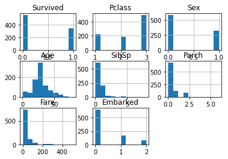

```python
df_new.hist()
```

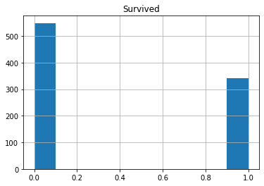

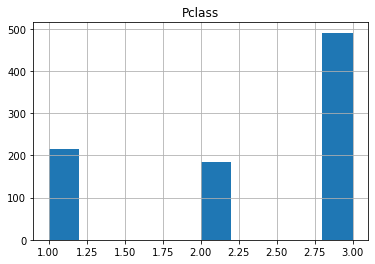

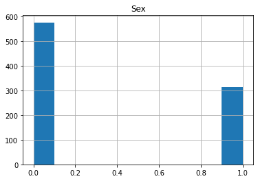

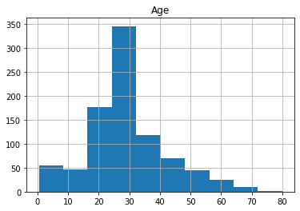

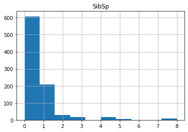

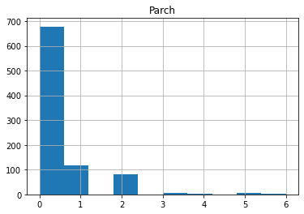

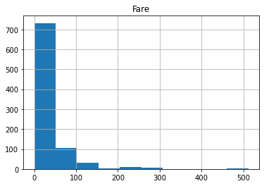

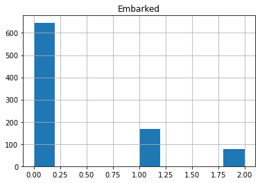

```python
Survived = df_new.hist("Survived")
Pclass = df_new.hist("Pclass")
Sex = df_new.hist("Sex")
Age = df_new.hist("Age")
SibSp = df_new.hist("SibSp")
Parch = df_new.hist("Parch")
Fare = df_new.hist("Fare")
Embarked = df_new.hist("Embarked")
```

# question 10

نرمال سازی داده ها از تفاضل داده ها با میانگین و سپس تقسیم بر انحراف معیار به دست می اید. نرمال سازی در مدل های یادگیری ماشین بسیار کمک کننده است.

```python
normal_df = (df_new-df_new.mean())/df_new.std()
normal_df.head()
```

|  | Survived | Pclass | Sex | Age | SibSp | Parch | Fare | Embarked |
| --- | --- | --- | --- | --- | --- | --- | --- | --- |
| 0 | -0.788829 | 0.826913 | -0.737281 | -0.592148 | 0.432550 | -0.473408 | -0.502163 | -0.568518 |
| 1 | 1.266279 | -1.565228 | 1.354813 | 0.638430 | 0.432550 | -0.473408 | 0.786404 | 1.004617 |
| 2 | 1.266279 | 0.826913 | 1.354813 | -0.284503 | -0.474279 | -0.473408 | -0.488580 | -0.568518 |
| 3 | 1.266279 | -1.565228 | 1.354813 | 0.407697 | 0.432550 | -0.473408 | 0.420494 | -0.568518 |
| 4 | -0.788829 | 0.826913 | -0.737281 | 0.407697 | -0.474279 | -0.473408 | -0.486064 | -0.568518 |

```
array([[<AxesSubplot:title={'center':'Survived'}>,
        <AxesSubplot:title={'center':'Pclass'}>,
        <AxesSubplot:title={'center':'Sex'}>],
       [<AxesSubplot:title={'center':'Age'}>,
        <AxesSubplot:title={'center':'SibSp'}>,
        <AxesSubplot:title={'center':'Parch'}>],
       [<AxesSubplot:title={'center':'Fare'}>,
        <AxesSubplot:title={'center':'Embarked'}>, <AxesSubplot:>]],
      dtype=object)
```

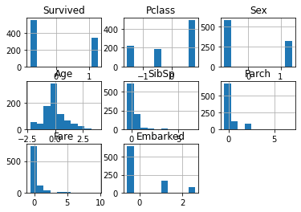

```python
normal_df.hist()
```

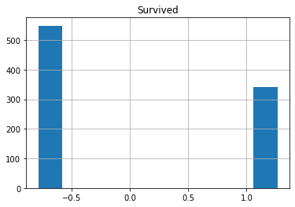

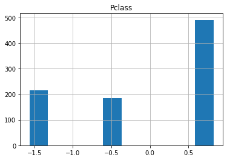

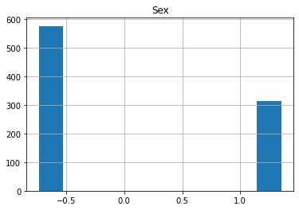

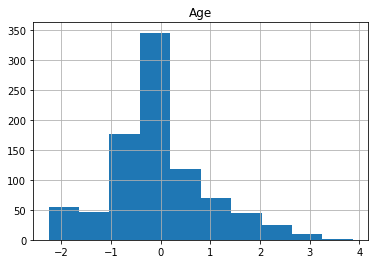

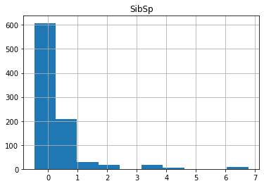

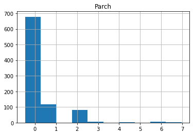

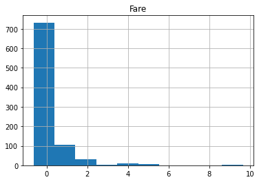

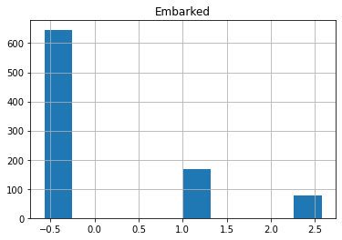

```python
Survived = normal_df.hist("Survived")
Pclass = normal_df.hist("Pclass")
Sex = normal_df.hist("Sex")
Age = normal_df.hist("Age")
SibSp = normal_df.hist("SibSp")
Parch = normal_df.hist("Parch")
Fare = normal_df.hist("Fare")
Embarked = normal_df.hist("Embarked")
```

# question 11

```python
from scipy.stats import norm
df_new.head()
```

|  | Survived | Pclass | Sex | Age | SibSp | Parch | Fare | Embarked |
| --- | --- | --- | --- | --- | --- | --- | --- | --- |
| 0 | 0 | 3 | 0 | 22.0 | 1 | 0 | 7.2500 | 0.0 |
| 1 | 1 | 1 | 1 | 38.0 | 1 | 0 | 71.2833 | 1.0 |
| 2 | 1 | 3 | 1 | 26.0 | 0 | 0 | 7.9250 | 0.0 |
| 3 | 1 | 1 | 1 | 35.0 | 1 | 0 | 53.1000 | 0.0 |
| 4 | 0 | 3 | 0 | 35.0 | 0 | 0 | 8.0500 | 0.0 |

در رسم دو نمودار مربوط به نوع بلیط میبینیم که هرچه نوع بلیط به سمت عدد 3 میرود تعداد کشته ها افزایش می یابد. پس با توجه به اینکه دو نمودار overlap کمتری دارند استفاده از این ویژگی میتواند مفید باشد.

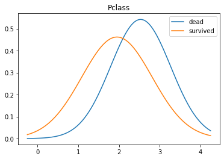

```python
Pclass_dead_mean = df_new[df_new['Survived']==0]['Pclass'].mean()
Pclass_dead_std = df_new[df_new['Survived']==0]['Pclass'].std()

Pclass_survived_mean = df_new[df_new['Survived']==1]['Pclass'].mean()
Pclass_survived_std = df_new[df_new['Survived']==1]['Pclass'].std()

Pclass_array = np.linspace(-0.25,4.25,100)
Pclass_dead_pdf = norm.pdf(Pclass_array,Pclass_dead_mean,Pclass_dead_std)
Pclass_survived_pdf = norm.pdf(Pclass_array,Pclass_survived_mean,Pclass_survived_std)

plt.plot(Pclass_array,Pclass_dead_pdf,label='dead')
plt.plot(Pclass_array,Pclass_survived_pdf,label='survived')
plt.title('Pclass')
plt.legend()
plt.show()

Pclass_min_index = np.argmin(abs(Pclass_survived_pdf-Pclass_dead_pdf))
Pclass_point = Pclass_array[Pclass_min_index]
```

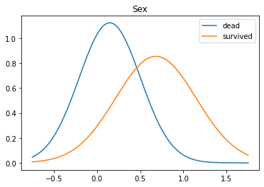

```python
Sex_dead_mean = df_new[df_new['Survived']==0]['Sex'].mean()
Sex_dead_std = df_new[df_new['Survived']==0]['Sex'].std()

Sex_survived_mean = df_new[df_new['Survived']==1]['Sex'].mean()
Sex_survived_std = df_new[df_new['Survived']==1]['Sex'].std()

Sex_array = np.linspace(-0.75,1.75,100)
Sex_dead_pdf = norm.pdf(Sex_array,Sex_dead_mean,Sex_dead_std)
Sex_survived_pdf = norm.pdf(Sex_array,Sex_survived_mean,Sex_survived_std)

plt.plot(Sex_array,Sex_dead_pdf,label='dead')
plt.plot(Sex_array,Sex_survived_pdf,label='survived')
plt.title('Sex')
plt.legend()
plt.show()

Sex_min_index = np.argmin(abs(Sex_survived_pdf-Sex_dead_pdf))
Sex_point = Sex_array[Sex_min_index]
```

دو نمودار مربوط به سن کاملا باهم overlap دارند پس از این ویژگی نمیتوان خیلی استفاده کرد.

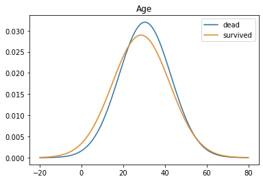

```python
Age_dead_mean = df_new[df_new['Survived']==0]['Age'].mean()
Age_dead_std = df_new[df_new['Survived']==0]['Age'].std()

Age_survived_mean = df_new[df_new['Survived']==1]['Age'].mean()
Age_survived_std = df_new[df_new['Survived']==1]['Age'].std()

Age_array = np.linspace(-20,80,100)
Age_dead_pdf = norm.pdf(Age_array,Age_dead_mean,Age_dead_std)
Age_survived_pdf = norm.pdf(Age_array,Age_survived_mean,Age_survived_std)

plt.plot(Age_array,Age_dead_pdf,label='dead')
plt.plot(Age_array,Age_survived_pdf,label='survived')
plt.title('Age')
plt.legend()
plt.show()
```

ویژگی تعداد خواهر برادر و همسر نیز کمک خاصی به ما نمیکند. از نطر منطقی نیز این ویژگی نباید تاثیری داشته باشد.

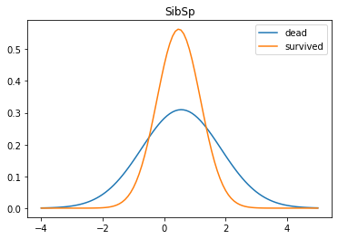

```python
SibSp_dead_mean = df_new[df_new['Survived']==0]['SibSp'].mean()
SibSp_dead_std = df_new[df_new['Survived']==0]['SibSp'].std()

SibSp_survived_mean = df_new[df_new['Survived']==1]['SibSp'].mean()
SibSp_survived_std = df_new[df_new['Survived']==1]['SibSp'].std()

SibSp_array = np.linspace(-4,5,100)
SibSp_dead_pdf = norm.pdf(SibSp_array,SibSp_dead_mean,SibSp_dead_std)
SibSp_survived_pdf = norm.pdf(SibSp_array,SibSp_survived_mean,SibSp_survived_std)

plt.plot(SibSp_array,SibSp_dead_pdf,label='dead')
plt.plot(SibSp_array,SibSp_survived_pdf,label='survived')
plt.title('SibSp')
plt.legend()
plt.show()
```

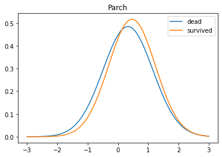

```python
Parch_dead_mean = df_new[df_new['Survived']==0]['Parch'].mean()
Parch_dead_std = df_new[df_new['Survived']==0]['Parch'].std()

Parch_survived_mean = df_new[df_new['Survived']==1]['Parch'].mean()
Parch_survived_std = df_new[df_new['Survived']==1]['Parch'].std()

Parch_array = np.linspace(-3,3,100)
Parch_dead_pdf = norm.pdf(Parch_array,Parch_dead_mean,Parch_dead_std)
Parch_survived_pdf = norm.pdf(Parch_array,Parch_survived_mean,Parch_survived_std)

plt.plot(Parch_array,Parch_dead_pdf,label='dead')
plt.plot(Parch_array,Parch_survived_pdf,label='survived')
plt.title('Parch')
plt.legend()
plt.show()
```

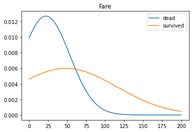

```python
Fare_dead_mean = df_new[df_new['Survived']==0]['Fare'].mean()
Fare_dead_std = df_new[df_new['Survived']==0]['Fare'].std()

Fare_survived_mean = df_new[df_new['Survived']==1]['Fare'].mean()
Fare_survived_std = df_new[df_new['Survived']==1]['Fare'].std()

Fare_array = np.linspace(0,200,1000)
Fare_dead_pdf = norm.pdf(Fare_array,Fare_dead_mean,Fare_dead_std)
Fare_survived_pdf = norm.pdf(Fare_array,Fare_survived_mean,Fare_survived_std)

plt.plot(Fare_array,Fare_dead_pdf,label='dead')
plt.plot(Fare_array,Fare_survived_pdf,label='survived')
plt.title('Fare')
plt.legend()
plt.show()

Fare_min_index = np.argmin(abs(Fare_survived_pdf-Fare_dead_pdf))
Fare_point = Fare_array[Fare_min_index]
```

میبینیم بندر هم تاثیر خاصی ندارد و نمودار ها overlap دارند. پس این ویژگی نیز اطلاعات خاصی در بر ندارد.

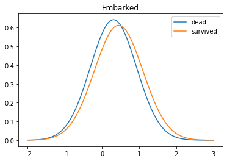

```python
Embarked_dead_mean = df_new[df_new['Survived']==0]['Embarked'].mean()
Embarked_dead_std = df_new[df_new['Survived']==0]['Embarked'].std()

Embarked_survived_mean = df_new[df_new['Survived']==1]['Embarked'].mean()
Embarked_survived_std = df_new[df_new['Survived']==1]['Embarked'].std()

Embarked_array = np.linspace(-2,3,100)
Embarked_dead_pdf = norm.pdf(Embarked_array,Embarked_dead_mean,Embarked_dead_std)
Embarked_survived_pdf = norm.pdf(Embarked_array,Embarked_survived_mean,Embarked_survived_std)

plt.plot(Embarked_array,Embarked_dead_pdf,label='dead')
plt.plot(Embarked_array,Embarked_survived_pdf,label='survived')
plt.title('Embarked')
plt.legend()
plt.show()
```

در نهایت فهمیدیم سه ویژگی جنسیت، نوع بلیط و قیمت میتواند ما را در راستای پیش بینی کردن کمک کند. همچنین میدانیم قیمت و نوع بلیط رابطه مستقیمی دارند. پس فقط از قیمت و جنسیت استفاده خواهیم کرد.

# question 12

```python
df_test = pd.read_csv("test.csv")
df_test.head()
```

|  | PassengerId | Pclass | Name | Sex | Age | SibSp | Parch | Ticket | Fare | Cabin | Embarked |
| --- | --- | --- | --- | --- | --- | --- | --- | --- | --- | --- | --- |
| 0 | 892 | 3 | Kelly, Mr. James | male | 34.5 | 0 | 0 | 330911 | 7.8292 | NaN | Q |
| 1 | 893 | 3 | Wilkes, Mrs. James (Ellen Needs) | female | 47.0 | 1 | 0 | 363272 | 7.0000 | NaN | S |
| 2 | 894 | 2 | Myles, Mr. Thomas Francis | male | 62.0 | 0 | 0 | 240276 | 9.6875 | NaN | Q |
| 3 | 895 | 3 | Wirz, Mr. Albert | male | 27.0 | 0 | 0 | 315154 | 8.6625 | NaN | S |
| 4 | 896 | 3 | Hirvonen, Mrs. Alexander (Helga E Lindqvist) | female | 22.0 | 1 | 1 | 3101298 | 12.2875 | NaN | S |

```python
df_test['Sex'].replace(['male','female'],[0,1],inplace=True)
df_test['Survived'] = 0
df_test
```

|  | PassengerId | Pclass | Name | Sex | Age | SibSp | Parch | Ticket | Fare | Cabin | Embarked | Survived |
| --- | --- | --- | --- | --- | --- | --- | --- | --- | --- | --- | --- | --- |
| 0 | 892 | 3 | Kelly, Mr. James | 0 | 34.5 | 0 | 0 | 330911 | 7.8292 | NaN | Q | 0 |
| 1 | 893 | 3 | Wilkes, Mrs. James (Ellen Needs) | 1 | 47.0 | 1 | 0 | 363272 | 7.0000 | NaN | S | 0 |
| 2 | 894 | 2 | Myles, Mr. Thomas Francis | 0 | 62.0 | 0 | 0 | 240276 | 9.6875 | NaN | Q | 0 |
| 3 | 895 | 3 | Wirz, Mr. Albert | 0 | 27.0 | 0 | 0 | 315154 | 8.6625 | NaN | S | 0 |
| 4 | 896 | 3 | Hirvonen, Mrs. Alexander (Helga E Lindqvist) | 1 | 22.0 | 1 | 1 | 3101298 | 12.2875 | NaN | S | 0 |
| ... | ... | ... | ... | ... | ... | ... | ... | ... | ... | ... | ... | ... |
| 413 | 1305 | 3 | Spector, Mr. Woolf | 0 | NaN | 0 | 0 | A.5. 3236 | 8.0500 | NaN | S | 0 |
| 414 | 1306 | 1 | Oliva y Ocana, Dona. Fermina | 1 | 39.0 | 0 | 0 | PC 17758 | 108.9000 | C105 | C | 0 |
| 415 | 1307 | 3 | Saether, Mr. Simon Sivertsen | 0 | 38.5 | 0 | 0 | SOTON/O.Q. 3101262 | 7.2500 | NaN | S | 0 |
| 416 | 1308 | 3 | Ware, Mr. Frederick | 0 | NaN | 0 | 0 | 359309 | 8.0500 | NaN | S | 0 |
| 417 | 1309 | 3 | Peter, Master. Michael J | 0 | NaN | 1 | 1 | 2668 | 22.3583 | NaN | C | 0 |

418 rows × 12 columns

```python
survived = []
for row in df_test.iterrows():
    if  (row[1]['Fare']<Fare_point) & (row[1]['Sex']<Sex_point)  :
        survived.append(0)

    else:
        survived.append(1)



df_test['Survived'] = survived
```

```python
df_test['Survived'].value_counts()
```

```
0    236
1    182
Name: Survived, dtype: int64
```

```python
df_test.to_csv("test_predicted.csv",index=False)
```